# Exploring Medalla data

Initial exploration.

Barnabé Monnot https://twitter.com/barnabemonnot (Robust Incentives Group, Ethereum Foundation)https://github.com/ethereum/rig  
2020-10-07

### Table of Contents

We are looking at the 20000 first slots.

## Aggregate attestations

eth2 is built to scale to tens of thousands of validators. This introduces overhead from message passing (and inclusion) when these validators are asked to vote on the canonical chain. To alleviate the beacon chain, votes (a.k.a. **attestations**) can be **aggregated**.

In particular, an attestation contains four attributes:

- The slot it is attesting for.
- Its vote for the head of the beacon chain, given by the fork choice rule.
- Its vote for the source, i.e., the last justified checkpoint in its view.
- Its vote for the target, i.e., the checkpoint to be justified in its view.

Since we expect validators to broadly agree in times of low latency, we also expect a lot of redundant attestations. We can aggregate such a set of attestations $I$ into a single, aggregate, attestation.

For each slot $s$, a committee of validator $C(s)$ is determined who is expected to attest for $s$. Assume that two aggregate attestations were formed from validators attesting for $s$, one aggregate of validators in set $I \subseteq C(s)$ and the other with validators in set $J \subseteq C(s)$. We have two cases:

- When the intersection of $I$ and $J$ is non-empty, we cannot aggregate the two aggregates further.
- When the intersection of $I$ and $J$ is empty, the two aggregates can themselves be aggregated, into one containing attestations from validator set $I \cup J$.

In the following, we look at redundant, clashing and individual attestations.

### How many individual attestations are contained in aggregates?

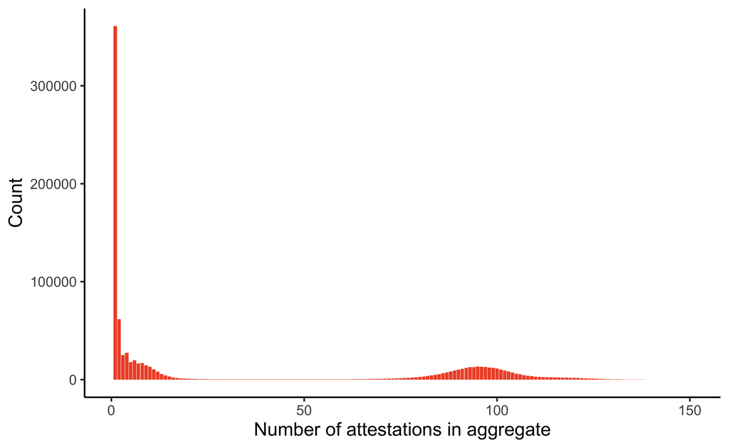

We can plot the same, weighing by the size of the validator set in the aggregate, to count how many individual attestations each size of aggregates included.

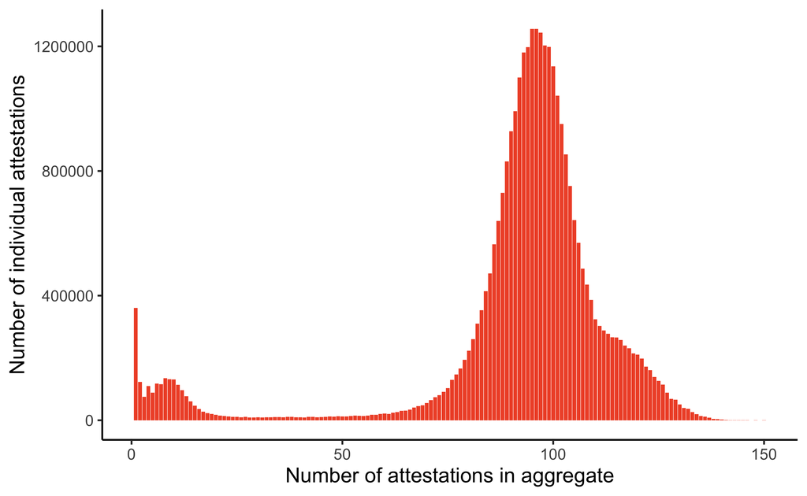

#### How much savings did aggregates provide?

We compare how many individual attestations exist to how many aggregates were included.

How many distinct individual attestations are there?

| Count |
| --- |
| 3426242 |

And how many aggregates were included in blocks?

| Count |
| --- |
| 928836 |

How much savings is that? The ratio of the first to the second.

| Savings |
| --- |
| 3.688748068 |

### In how many aggregate attestations is a single attestation included?

We look at all *individual* attestations in our dataset, i.e., individual, unaggregated votes, and measure how many times they were included in an aggregate.

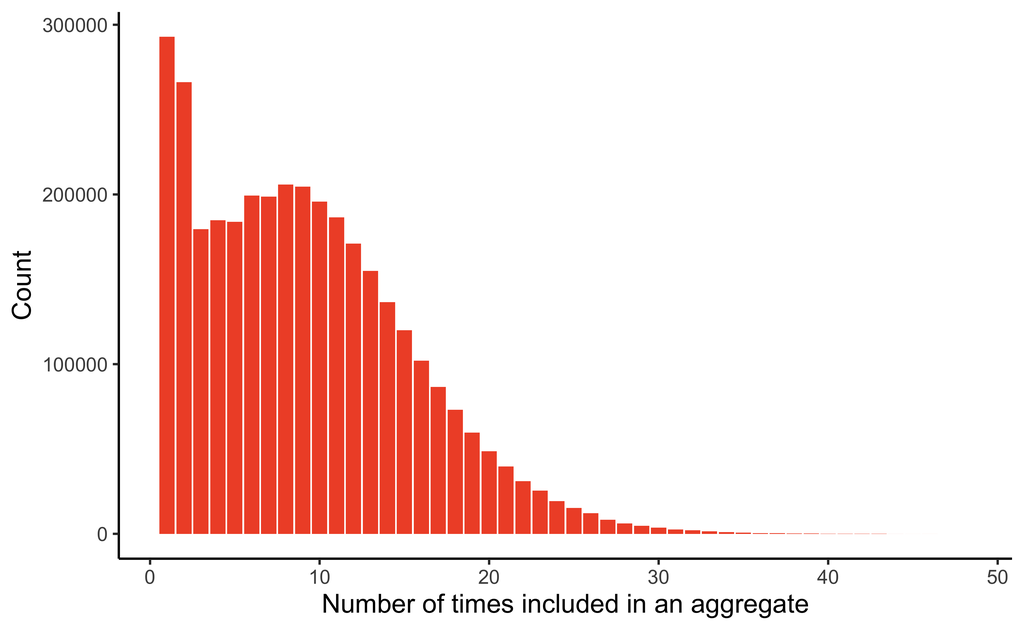

### How many redundant aggregate attestations are there?

We call **redundant** identical aggregate attestations (same four attributes and same set of validator indices) which are included in more than one block. It can happen when a block producer does not see that an aggregate was previously included (e.g., because of latency), or simply when the block producer doesn’t pay attention and greedily adds as many aggregates as they know about.

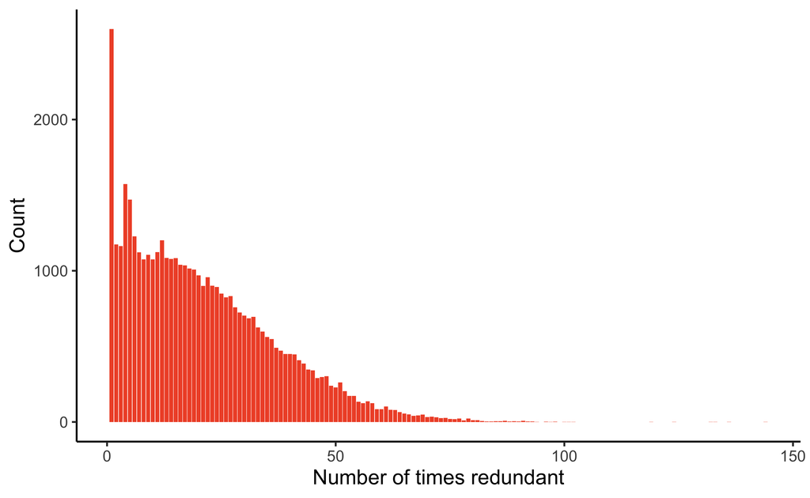

The mode is 1, which is also the optimal case. A redundant aggregate does not have much purpose apart from bloating the chain.

### How many times did a block include the exact same aggregate attestation more than once?

We could call these **strongly redundant**, as this is pure waste.

| n | count |
| --- | --- |
| 1 | 910922 |
| 2 | 8568 |
| 3 | 254 |
| 4 | 4 |

### How many times were clashing attestations included in blocks?

We define **clashing** attestations as two aggregate attestations included in the same block, with identical attributes (same attesting slot, beacon chain head, source block and target block). We can further define the following two notions, assuming the two aggregate attestations include attestations of validator sets $I$ and $J$ respectively:

- **Weakly clashing:** the two aggregates have different validator indices, $I \neq J$.
- **Strongly clashing:** $I \neq J$ **and** $I \cap J \neq \emptyset$. The two aggregate attestations were incompatible, so could not be aggregated further.

We obtain how many times an attestation weakly clashes with itself, i.e., is included multiple times in a single block with different validator sets. For instance, if an aggregate attestation is included in the same block three times with a different set of validator indices each time, we record that this aggregate is weakly clashing three times with itself. We give below the histogram of this measure.

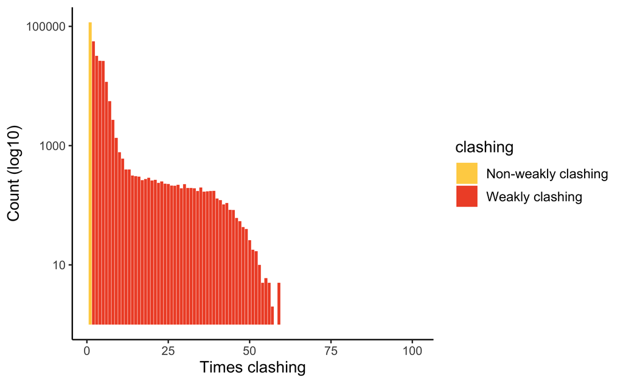

From the plot above, we observe that some aggregates were included over 40 times in the same block, all with different sets of validator indices. Still, most aggregates were included once or a few times.

Finding weakly clashing attestations that are not strongly clashing (i.e., which could have been aggregated further) is left for future work as it is more computationally intensive. In particular, for a set of aggregates identical up to their validator indices, one must find which have an empty overlap.

Note that optimally aggregating a set of aggregates is NP-complete! Here is a reduction of the optimal aggregation problem to the [graph colouring](https://en.wikipedia.org/wiki/Graph_coloring). Set aggregate attestations as vertices in a graph, with an edge drawn between two vertices if the validator sets of the two aggregates have a non-empty overlap. In the graph colouring, we look for the minimum number of colours necessary to assign a colour to each vertex such that two connected vertices do not have the same colour. All vertices who share the same colour have an empty overlap, and thus can be combined into an aggregate. The minimum number of colours necessary to colour the graph tells us how few aggregates were necessary to combine a given set of aggregates further.

## Inclusion delay

We turn our attention to the inclusion delay. Validators are rewarded for attesting timely, with higher rewards the earlier they are included in a block. We explode aggregates contained in the blocks to trace the earliest included attestation of each validator in an epoch.

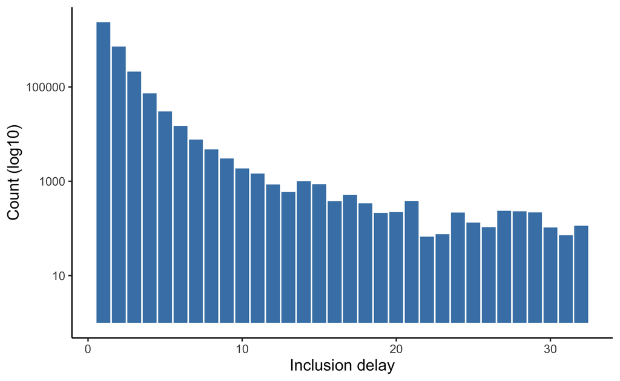

Note that the y axis is given on a logarithmic scale. A high number of attestations have a low inclusion delay, which is good! Since attestations cannot be included more than 32 slots from their attesting slot, the distribution above is naturally capped at 32.